# Multiple Linear Regression and Variable Selection in R

Josue Iradukunda

2026-11-09

# Introduction

This assignment demonstrates how to:

1. identify and describe a dataset suitable for multiple linear regression;
2. fit and interpret a multiple linear regression model;
3. assess model fit and examine regression assumptions; and
4. explain and apply common variable-selection methods in R.

The analysis uses the built-in **`mtcars`** dataset.

## 1.2 Load and inspect the data

```r
data(mtcars)
cars <- mtcars

# Convert transmission to a factor so R treats it as categorical
cars$am <- factor(cars$am,
                  levels = c(0, 1),
                  labels = c("Automatic", "Manual"))

head(cars)
```

```
##                    mpg cyl disp  hp drat    wt  qsec vs        am gear carb
## Mazda RX4         21.0   6  160 110 3.90 2.620 16.46  0    Manual    4    4
## Mazda RX4 Wag     21.0   6  160 110 3.90 2.875 17.02  0    Manual    4    4
## Datsun 710        22.8   4  108  93 3.85 2.320 18.61  1    Manual    4    1
## Hornet 4 Drive    21.4   6  258 110 3.08 3.215 19.44  1 Automatic    3    1
## Hornet Sportabout 18.7   8  360 175 3.15 3.440 17.02  0 Automatic    3    2
## Valiant           18.1   6  225 105 2.76 3.460 20.22  1 Automatic    3    1
```

```r
str(cars)
```

```
## 'data.frame':    32 obs. of  11 variables:
##  $ mpg : num  21 21 22.8 21.4 18.7 18.1 14.3 24.4 22.8 19.2 ...
##  $ cyl : num  6 6 4 6 8 6 8 4 4 6 ...
##  $ disp: num  160 160 108 258 360 ...
##  $ hp  : num  110 110 93 110 175 105 245 62 95 123 ...
##  $ drat: num  3.9 3.9 3.85 3.08 3.15 2.76 3.21 3.69 3.92 3.92 ...
##  $ wt  : num  2.62 2.88 2.32 3.21 3.44 ...
##  $ qsec: num  16.5 17 18.6 19.4 17 ...
##  $ vs  : num  0 0 1 1 0 1 0 1 1 1 ...
##  $ am  : Factor w/ 2 levels "Automatic","Manual": 2 2 2 1 1 1 1 1 1 1 ...
##  $ gear: num  4 4 4 3 3 3 3 4 4 4 ...
##  $ carb: num  4 4 1 1 2 1 4 2 2 4 ...
```

```r
dim(cars)
```

```
## [1] 32 11
```

```r
summary(cars)
```

```
##       mpg             cyl             disp             hp
##  Min.   :10.40   Min.   :4.000   Min.   : 71.1   Min.   : 52.0
##  1st Qu.:15.43   1st Qu.:4.000   1st Qu.:120.8   1st Qu.: 96.5
##  Median :19.20   Median :6.000   Median :196.3   Median :123.0
##  Mean   :20.09   Mean   :6.188   Mean   :230.7   Mean   :146.7
##  3rd Qu.:22.80   3rd Qu.:8.000   3rd Qu.:326.0   3rd Qu.:180.0
##  Max.   :33.90   Max.   :8.000   Max.   :472.0   Max.   :335.0
##       drat             wt             qsec             vs
##  Min.   :2.760   Min.   :1.513   Min.   :14.50   Min.   :0.0000
##  1st Qu.:3.080   1st Qu.:2.581   1st Qu.:16.89   1st Qu.:0.0000
##  Median :3.695   Median :3.325   Median :17.71   Median :0.0000
##  Mean   :3.597   Mean   :3.217   Mean   :17.85   Mean   :0.4375
##  3rd Qu.:3.920   3rd Qu.:3.610   3rd Qu.:18.90   3rd Qu.:1.0000
##  Max.   :4.930   Max.   :5.424   Max.   :22.90   Max.   :1.0000
##          am          gear            carb
##  Automatic:19   Min.   :3.000   Min.   :1.000
##  Manual   :13   1st Qu.:3.000   1st Qu.:2.000
##                 Median :4.000   Median :2.000
##                 Mean   :3.688   Mean   :2.812
##                 3rd Qu.:4.000   3rd Qu.:4.000
##                 Max.   :5.000   Max.   :8.000
```

There are 32 observations (cars) and 11 variables in the original dataset. The `am` variable is converted to a factor because transmission type represents categories, not a numerical measurement.

## 1.3 Check missing values

```r
colSums(is.na(cars))
```

```
##  mpg  cyl disp   hp drat   wt qsec   vs   am gear carb
##    0    0    0    0    0    0    0    0    0    0    0
```

The original `mtcars` dataset has no missing values. Therefore, all 32 observations can be used in the model.

## 1.4 Explore the response and predictors

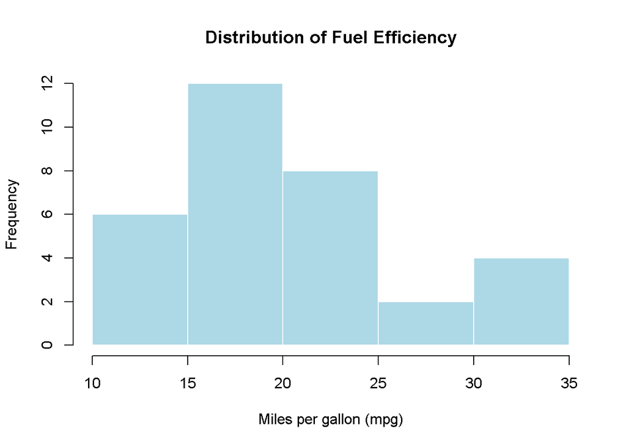

```r
hist(cars$mpg,
     main = "Distribution of Fuel Efficiency",
     xlab = "Miles per gallon (mpg)",
     col = "lightblue",
     border = "white")
```

```r
# Correlations among the numeric variables
numeric_cars <- cars[sapply(cars, is.numeric)]
round(cor(numeric_cars), 2)
```

```
##        mpg   cyl  disp    hp  drat    wt  qsec    vs  gear  carb
## mpg   1.00 -0.85 -0.85 -0.78  0.68 -0.87  0.42  0.66  0.48 -0.55
## cyl  -0.85  1.00  0.90  0.83 -0.70  0.78 -0.59 -0.81 -0.49  0.53
## disp -0.85  0.90  1.00  0.79 -0.71  0.89 -0.43 -0.71 -0.56  0.39
## hp   -0.78  0.83  0.79  1.00 -0.45  0.66 -0.71 -0.72 -0.13  0.75
## drat  0.68 -0.70 -0.71 -0.45  1.00 -0.71  0.09  0.44  0.70 -0.09
## wt   -0.87  0.78  0.89  0.66 -0.71  1.00 -0.17 -0.55 -0.58  0.43
## qsec  0.42 -0.59 -0.43 -0.71  0.09 -0.17  1.00  0.74 -0.21 -0.66
## vs    0.66 -0.81 -0.71 -0.72  0.44 -0.55  0.74  1.00  0.21 -0.57
## gear  0.48 -0.49 -0.56 -0.13  0.70 -0.58 -0.21  0.21  1.00  0.27
## carb -0.55  0.53  0.39  0.75 -0.09  0.43 -0.66 -0.57  0.27  1.00
```

A correlation describes the strength and direction of a pairwise linear association. Correlation alone does not establish causation, and strong correlations among predictors can make individual regression coefficients less stable.

# 2. Multiple linear regression

## 2.1 What is multiple linear regression?

Multiple linear regression models the relationship between one continuous response variable and two or more explanatory variables.

The general model is:

$$Y_i = \beta_0 + \beta_1X_{i1} + \beta_2X_{i2}
+ \cdots + \beta_pX_{ip} + \epsilon_i$$

Where:

- $Y_i$ is the response for observation $i$;
- $\beta_0$ is the intercept;
- $\beta_j$ is the coefficient for predictor $j$;
- $X_{ij}$ is the value of predictor $j$ for observation $i$; and
- $\epsilon_i$ is the error term.

For this assignment, fuel efficiency (`mpg`) is the response variable.

## 2.2 Fit the initial multiple regression model

We begin with six predictors: weight, horsepower, quarter-mile time, transmission, displacement, and rear axle ratio.

```r
full_model <- lm(
  mpg ~ wt + hp + qsec + am + disp + drat,
  data = cars
)

summary(full_model)
```

```
##
## Call:
## lm(formula = mpg ~ wt + hp + qsec + am + disp + drat, data = cars)
##
## Residuals:
##     Min      1Q  Median      3Q     Max
## -3.2669 -1.6148 -0.2585  1.1220  4.5564
##
## Coefficients:
##             Estimate Std. Error t value Pr(>|t|)
## (Intercept) 10.71062   10.97539   0.976  0.33848
## wt          -4.04454    1.20558  -3.355  0.00254 **
## hp          -0.02180    0.01465  -1.488  0.14938
## qsec         0.99073    0.48002   2.064  0.04955 *
## amManual     2.98469    1.63382   1.827  0.07969 .
## disp         0.01310    0.01098   1.193  0.24405
## drat         1.02065    1.36748   0.746  0.46240
## ---
## Signif. codes:  0 '***' 0.001 '**' 0.01 '*' 0.05 '.' 0.1 ' ' 1
##
## Residual standard error: 2.45 on 25 degrees of freedom
## Multiple R-squared:  0.8667, Adjusted R-squared:  0.8347
## F-statistic: 27.09 on 6 and 25 DF,  p-value: 8.637e-10
```

The `lm()` function fits a linear model. The `summary()` function displays coefficient estimates, standard errors, t-statistics, p-values, residual standard error, R-squared, adjusted R-squared, and the overall F-test.

## 2.3 Extract important model statistics

```r
model_summary <- summary(full_model)

cat("R-squared:", round(model_summary$r.squared, 3), "\n")
```

```
## R-squared: 0.867
```

```r
cat("Adjusted R-squared:", round(model_summary$adj.r.squared, 3), "\n")
```

```
## Adjusted R-squared: 0.835
```

```r
cat("Residual standard error:", round(model_summary$sigma, 3), "\n")
```

```
## Residual standard error: 2.45
```

```r
cat("Overall F-test p-value:",
    signif(pf(model_summary$fstatistic[1],
              model_summary$fstatistic[2],
              model_summary$fstatistic[3],
              lower.tail = FALSE), 4),
    "\n")
```

```
## Overall F-test p-value: 8.637e-10
```

## 2.4 Make predictions

The following code predicts fuel efficiency for a hypothetical car. The values are illustrative and are not an additional observation from the dataset.

```r
new_car <- data.frame(
  wt = 3.0,
  hp = 120,
  qsec = 17.5,
  am = factor("Manual", levels = levels(cars$am)),
  disp = 200,
  drat = 3.5
)

predict(full_model, newdata = new_car, interval = "confidence")
```

```
##        fit      lwr      upr
## 1 22.47657 20.26076 24.69239
```

The fitted value is the model’s estimated mean mpg for cars with these characteristics. The confidence interval describes uncertainty in the estimated mean response, not the range for an individual car.

# 3. Checking regression assumptions

Regression diagnostics help assess whether the model is an appropriate description of the data. They do not prove that every assumption is true.

## 3.1 Linearity and residual patterns

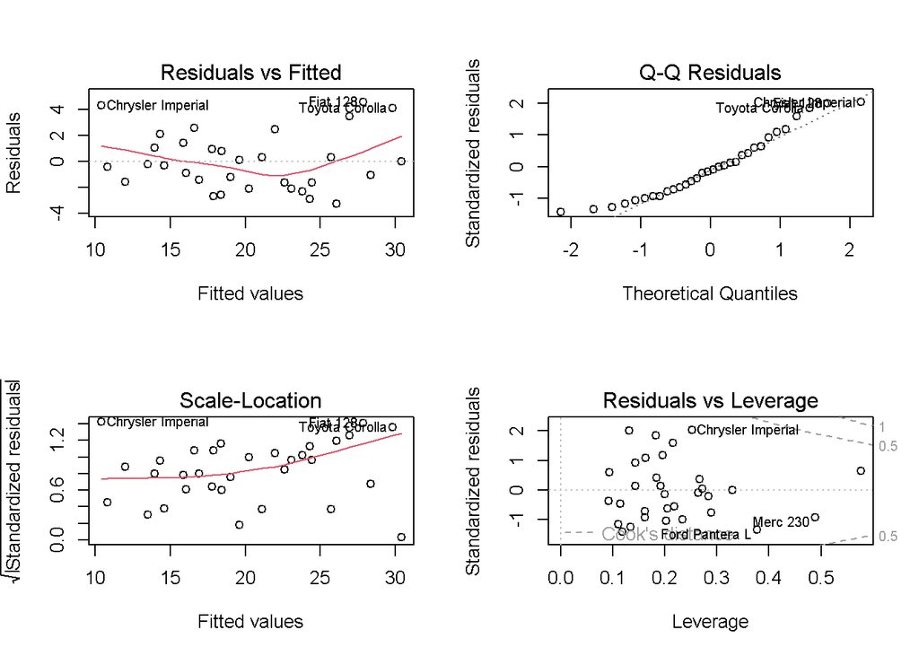

```r
par(mfrow = c(2, 2))
plot(full_model)
```

```r
par(mfrow = c(1, 1))
```

Interpret the diagnostic plots as follows:

1. **Residuals vs Fitted:** residuals should be scattered around zero without a clear curve or systematic pattern. A curved pattern may indicate non-linearity.
2. **Normal Q-Q:** points should lie approximately along the reference line if residuals are approximately normally distributed.
3. **Scale-Location:** a roughly horizontal band with similar spread supports constant variance.
4. **Residuals vs Leverage:** observations with unusually high leverage or influence deserve investigation.

## 3.2 Normality of residuals

```r
shapiro.test(residuals(full_model))
```

```
##
##  Shapiro-Wilk normality test
##
## data:  residuals(full_model)
## W = 0.9446, p-value = 0.1012
```

The Shapiro-Wilk test has a null hypothesis that the residuals are normally distributed. A p-value below 0.05 suggests evidence against normality. Consider this test together with the Q-Q plot; with a small sample, neither should be treated as a perfect decision rule.

## 3.3 Constant variance

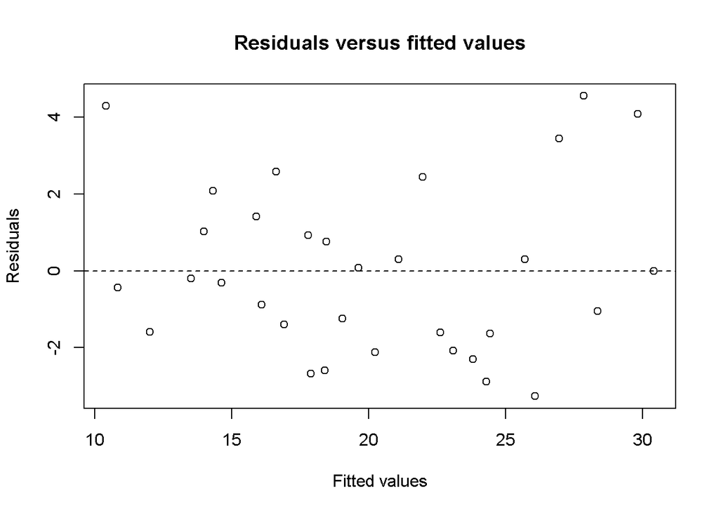

```r
plot(fitted(full_model), residuals(full_model),
     xlab = "Fitted values",
     ylab = "Residuals",
     main = "Residuals versus fitted values")
abline(h = 0, lty = 2)
```

Look for a reasonably even vertical spread across fitted values. A funnel-shaped pattern may indicate non-constant error variance.

## 3.4 Multicollinearity

Multicollinearity occurs when explanatory variables are strongly related to one another. It can make coefficient estimates unstable and increase their standard errors.

A simple way to investigate it is to inspect the predictor correlation matrix shown earlier. A more formal diagnostic is the variance inflation factor (VIF). The following base-R code calculates VIF values without requiring an extra package.

```r
predictor_names <- c("wt", "hp", "qsec", "am", "disp", "drat")

vif_values <- sapply(predictor_names, function(variable) {
  other_predictors <- setdiff(predictor_names, variable)
  auxiliary_formula <- reformulate(other_predictors, response = variable)
  auxiliary_model <- lm(auxiliary_formula, data = cars)
  1 / (1 - summary(auxiliary_model)$r.squared)
})

round(vif_values, 2)
```

```
##   wt   hp qsec   am disp drat
## 7.18 5.21 3.80   NA 9.57 2.76
```

VIF measures how much the variance of a coefficient is inflated because of linear relationships with the other predictors. Values around 1 indicate little linear association with the other predictors; larger values deserve attention. Rules such as 5 or 10 are only rough guidelines, not universal cut-offs.

## 3.5 Independence

Independence concerns how observations and their errors relate to one another. The `mtcars` data are observations of different cars, not a time series. However, independence should ultimately be justified by how the data were collected; it cannot be established from a single diagnostic plot.

# 4. Apply variable selection in R

We will compare forward, backward, and bidirectional selection using the same candidate predictor set. R’s built-in `step()` function performs stepwise model selection using AIC by default.

## 4.1 Define the upper and lower models

```r
null_model <- lm(mpg ~ 1, data = cars)

full_candidate_model <- lm(
  mpg ~ wt + hp + qsec + am + disp + drat,
  data = cars
)

# Define the range of models that the search may consider
selection_scope <- list(
  lower = formula(null_model),
  upper = formula(full_candidate_model)
)
```

## 4.2 Forward selection

```r
forward_model <- step(
  null_model,
  scope = selection_scope,
  direction = "forward",
  trace = 0
)

summary(forward_model)
```

```
##
## Call:
## lm(formula = mpg ~ wt + hp + am + qsec, data = cars)
##
## Residuals:
##     Min      1Q  Median      3Q     Max
## -3.4975 -1.5902 -0.1122  1.1795  4.5404
##
## Coefficients:
##             Estimate Std. Error t value Pr(>|t|)
## (Intercept) 17.44019    9.31887   1.871  0.07215 .
## wt          -3.23810    0.88990  -3.639  0.00114 **
## hp          -0.01765    0.01415  -1.247  0.22309
## amManual     2.92550    1.39715   2.094  0.04579 *
## qsec         0.81060    0.43887   1.847  0.07573 .
## ---
## Signif. codes:  0 '***' 0.001 '**' 0.01 '*' 0.05 '.' 0.1 ' ' 1
##
## Residual standard error: 2.435 on 27 degrees of freedom
## Multiple R-squared:  0.8579, Adjusted R-squared:  0.8368
## F-statistic: 40.74 on 4 and 27 DF,  p-value: 4.589e-11
```

```r
formula(forward_model)
```

```
## mpg ~ wt + hp + am + qsec
```

```r
AIC(forward_model)
```

```
## [1] 154.3274
```

This starts with the intercept-only model and adds predictors when doing so reduces AIC.

## 4.3 Backward elimination

```r
backward_model <- step(
  full_candidate_model,
  direction = "backward",
  trace = 0
)

summary(backward_model)
```

```
##
## Call:
## lm(formula = mpg ~ wt + qsec + am, data = cars)
##
## Residuals:
##     Min      1Q  Median      3Q     Max
## -3.4811 -1.5555 -0.7257  1.4110  4.6610
##
## Coefficients:
##             Estimate Std. Error t value Pr(>|t|)
## (Intercept)   9.6178     6.9596   1.382 0.177915
## wt           -3.9165     0.7112  -5.507 6.95e-06 ***
## qsec          1.2259     0.2887   4.247 0.000216 ***
## amManual      2.9358     1.4109   2.081 0.046716 *
## ---
## Signif. codes:  0 '***' 0.001 '**' 0.01 '*' 0.05 '.' 0.1 ' ' 1
##
## Residual standard error: 2.459 on 28 degrees of freedom
## Multiple R-squared:  0.8497, Adjusted R-squared:  0.8336
## F-statistic: 52.75 on 3 and 28 DF,  p-value: 1.21e-11
```

```r
formula(backward_model)
```

```
## mpg ~ wt + qsec + am
```

```r
AIC(backward_model)
```

```
## [1] 154.1194
```

This starts with all six candidate predictors and removes terms when doing so reduces AIC.

## 4.4 Bidirectional stepwise selection

```r
both_model <- step(
  null_model,
  scope = selection_scope,
  direction = "both",
  trace = 0
)

summary(both_model)
```

```
##
## Call:
## lm(formula = mpg ~ wt + am + qsec, data = cars)
##
## Residuals:
##     Min      1Q  Median      3Q     Max
## -3.4811 -1.5555 -0.7257  1.4110  4.6610
##
## Coefficients:
##             Estimate Std. Error t value Pr(>|t|)
## (Intercept)   9.6178     6.9596   1.382 0.177915
## wt           -3.9165     0.7112  -5.507 6.95e-06 ***
## amManual      2.9358     1.4109   2.081 0.046716 *
## qsec          1.2259     0.2887   4.247 0.000216 ***
## ---
## Signif. codes:  0 '***' 0.001 '**' 0.01 '*' 0.05 '.' 0.1 ' ' 1
##
## Residual standard error: 2.459 on 28 degrees of freedom
## Multiple R-squared:  0.8497, Adjusted R-squared:  0.8336
## F-statistic: 52.75 on 3 and 28 DF,  p-value: 1.21e-11
```

```r
formula(both_model)
```

```
## mpg ~ wt + am + qsec
```

```r
AIC(both_model)
```

```
## [1] 154.1194
```

This starts from the null model and allows the search to add or remove predictors within the defined scope.

## 4.5 Compare the selected models

```r
model_comparison <- data.frame(
  Method = c("Initial full model",
             "Forward selection",
             "Backward elimination",
             "Bidirectional stepwise"),
  Number_of_predictors = c(
    length(attr(terms(full_candidate_model), "term.labels")),
    length(attr(terms(forward_model), "term.labels")),
    length(attr(terms(backward_model), "term.labels")),
    length(attr(terms(both_model), "term.labels"))
  ),
  AIC = c(
    AIC(full_candidate_model),
    AIC(forward_model),
    AIC(backward_model),
    AIC(both_model)
  ),
  Adjusted_R_squared = c(
    summary(full_candidate_model)$adj.r.squared,
    summary(forward_model)$adj.r.squared,
    summary(backward_model)$adj.r.squared,
    summary(both_model)$adj.r.squared
  )
)

model_comparison[order(model_comparison$AIC), ]
```

```
##                   Method Number_of_predictors      AIC Adjusted_R_squared
## 3   Backward elimination                    3 154.1194          0.8335561
## 4 Bidirectional stepwise                    3 154.1194          0.8335561
## 2      Forward selection                    4 154.3274          0.8367919
## 1     Initial full model                    6 156.2687          0.8347177
```

For models fitted to the same response and observations, lower AIC indicates a better trade-off between fit and complexity according to AIC. The table also shows the number of predictors and adjusted R-squared.

Forward, backward, and bidirectional searches may sometimes produce the same model, but this is not guaranteed. Their result depends on the candidate variables, starting model, and selection criterion.

## 4.6 Use BIC instead of AIC

The `step()` function uses AIC by default. Setting `k = log(n)` applies the BIC penalty.

```r
bic_model <- step(
  full_candidate_model,
  direction = "backward",
  k = log(nrow(cars)),
  trace = 0
)

summary(bic_model)
```

```
##
## Call:
## lm(formula = mpg ~ wt + qsec + am, data = cars)
##
## Residuals:
##     Min      1Q  Median      3Q     Max
## -3.4811 -1.5555 -0.7257  1.4110  4.6610
##
## Coefficients:
##             Estimate Std. Error t value Pr(>|t|)
## (Intercept)   9.6178     6.9596   1.382 0.177915
## wt           -3.9165     0.7112  -5.507 6.95e-06 ***
## qsec          1.2259     0.2887   4.247 0.000216 ***
## amManual      2.9358     1.4109   2.081 0.046716 *
## ---
## Signif. codes:  0 '***' 0.001 '**' 0.01 '*' 0.05 '.' 0.1 ' ' 1
##
## Residual standard error: 2.459 on 28 degrees of freedom
## Multiple R-squared:  0.8497, Adjusted R-squared:  0.8336
## F-statistic: 52.75 on 3 and 28 DF,  p-value: 1.21e-11
```

```r
formula(bic_model)
```

```
## mpg ~ wt + qsec + am
```

```r
BIC(bic_model)
```

```
## [1] 161.4481
```

BIC often favors a more compact model than AIC, although the result depends on the data.

## 4.7 Interpret the selected model

```r
cat("Selected model formula:\n")
```

```
## Selected model formula:
```

```r
print(formula(both_model))
```

```
## mpg ~ wt + am + qsec
```

```r
cat("\nSelected model summary:\n")
```

```
##
## Selected model summary:
```

```r
summary(both_model)
```

```
##
## Call:
## lm(formula = mpg ~ wt + am + qsec, data = cars)
##
## Residuals:
##     Min      1Q  Median      3Q     Max
## -3.4811 -1.5555 -0.7257  1.4110  4.6610
##
## Coefficients:
##             Estimate Std. Error t value Pr(>|t|)
## (Intercept)   9.6178     6.9596   1.382 0.177915
## wt           -3.9165     0.7112  -5.507 6.95e-06 ***
## amManual      2.9358     1.4109   2.081 0.046716 *
## qsec          1.2259     0.2887   4.247 0.000216 ***
## ---
## Signif. codes:  0 '***' 0.001 '**' 0.01 '*' 0.05 '.' 0.1 ' ' 1
##
## Residual standard error: 2.459 on 28 degrees of freedom
## Multiple R-squared:  0.8497, Adjusted R-squared:  0.8336
## F-statistic: 52.75 on 3 and 28 DF,  p-value: 1.21e-11
```

```r
cat("\nSelected model adjusted R-squared:\n")
```

```
##
## Selected model adjusted R-squared:
```

```r
round(summary(both_model)$adj.r.squared, 3)
```

```
## [1] 0.834
```

To interpret the selected model:

1. Identify the predictors retained in `formula(both_model)`.
2. Read each coefficient and its sign.
3. Interpret each coefficient while holding the other selected predictors constant.
4. Check the p-values and confidence intervals, but do not treat selection-based p-values as if the model had been specified in advance.
5. Compare adjusted R-squared and AIC with the initial model.
6. Consider whether the selected variables make practical and subject-matter sense.

## 4.8 Important limitations of automatic selection

Automatic selection is useful for learning and exploratory analysis, but it has important limitations:

- Small changes in the data can lead to a different selected model.
- Repeated searching can make ordinary p-values and confidence intervals too optimistic.
- A selected association does not demonstrate causation.
- AIC or BIC selection does not replace subject-matter knowledge.
- A model selected on the same data used to evaluate it may appear more accurate than it will be on new data.

For predictive work, assess performance on separate test data or by cross-validation. For scientific inference, decide on important predictors using theory and study design, and account for the selection process.

# 5. References

1. R Core Team. *R: A language and environment for statistical computing*. The `mtcars` dataset is included with R.
2. R Core Team. *R Documentation: Choose a model by AIC in a Stepwise Algorithm (`stats::step`)*. https://stat.ethz.ch/R-manual/R-devel/library/stats/html/step.html
3. R Companion. *Multiple Regression*. https://rcompanion.org/rcompanion/e_05.html